# Customer Characteristics that Affect Loan Status and Amount

## Investigation Overview

In this investigation I seek to explore what factors affect a customer's likelihood to get financed for a loan and the loan's outcome status i.e. whether or not the loan is paid back. Factors which I mainly focussed on included: IncomeRange, IncomeVerifiable, LoanStatus and ProsperScore.

## Dataset Overview

The data consisted of 113937 observations, 81 features. The attributes included the fore-mentioned attributes and others such as Investors. I didn't drop any columns but instead filtered through the values in order to obtain the target dataset.

```
Employed         98784
Not available     5346
Other             3680
Not employed      1598
Name: EmploymentStatus, dtype: int64
```

## Loan Status vs Income Range

Most of the loanees are employed. Most current loans are owed by the low-middle income ranges of between 25000-74999. It seems odd that people that people earning more than 100000 have more current loans than people in the income range between 75000-99999.

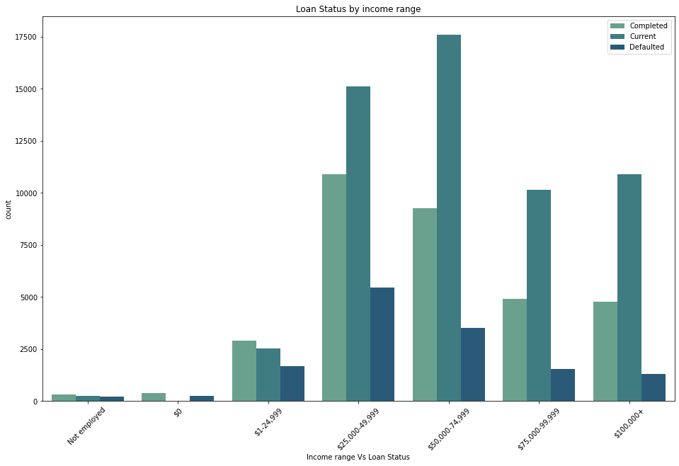

## Prosper Score Vs Loan Status

Most current loans are owed by loanees with a prosper score of 4.0. Most completed loans are by people with a prosper score of 8.0. Most likely to default are by people with a prosper score of between 4.0 to 8.0

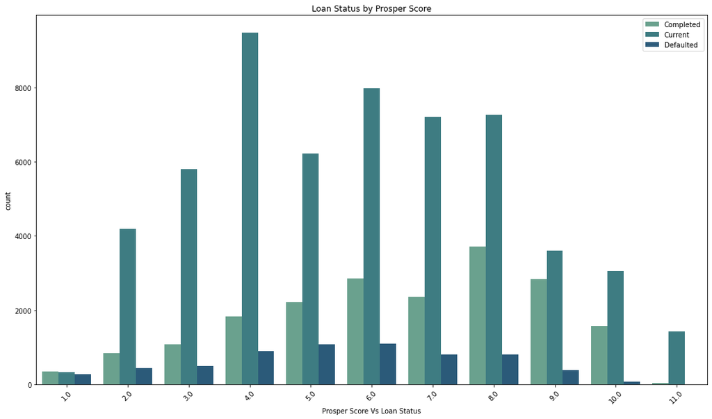

## Prosper Score Vs Investors

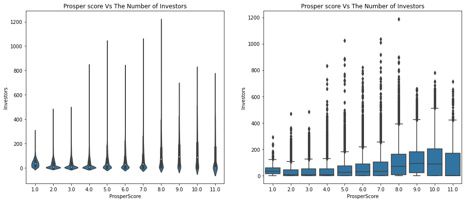

## Income Range, Investors and Verifiable Income

People with a verifiable source of income tend to have more investors. Income Verifiability seems to increase as you move up the income ranges

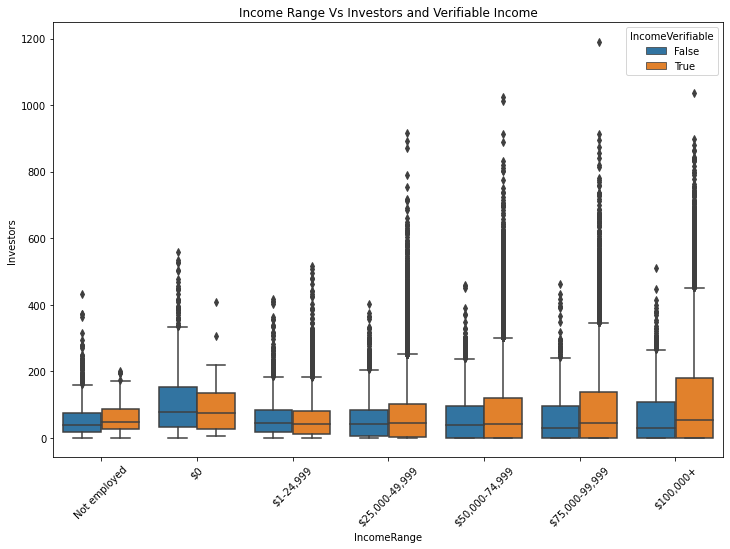